# Copia de EDA Airbnb

# Analisis nulos

```python
df.info()
```

```
<class 'pandas.core.frame.DataFrame'>
Int64Index: 30120 entries, 0 to 48894
Data columns (total 13 columns):
 #   Column                          Non-Null Count  Dtype
---  ------                          --------------  -----
 0   host_id                         30120 non-null  int64
 1   neighbourhood_group             30120 non-null  object
 2   neighbourhood                   30120 non-null  object
 3   latitude                        30120 non-null  float64
 4   longitude                       30120 non-null  float64
 5   room_type                       30120 non-null  object
 6   price                           30103 non-null  float64
 7   minimum_nights                  30120 non-null  int64
 8   number_of_reviews               30120 non-null  int64
 9   last_review                     25585 non-null  object
 10  reviews_per_month               25585 non-null  float64
 11  calculated_host_listings_count  30120 non-null  int64
 12  availability_365                30120 non-null  int64
dtypes: float64(4), int64(5), object(4)
memory usage: 3.2+ MB
```

```python
# NO HAY APARTAMENTOS CON REVIEWS Y A SU VEZ REVIEWS_PER_MONTH NULAS
df.loc[df.reviews_per_month.isna() & (df.number_of_reviews > 0)]
```

|  | host_id | neighbourhood_group | neighbourhood | latitude | longitude | room_type | price | minimum_nights | number_of_reviews | last_review | reviews_per_month | calculated_host_listings_count | availability_365 |
| --- | --- | --- | --- | --- | --- | --- | --- | --- | --- | --- | --- | --- | --- |

```python
# Descartamos los nulos en precio porque es la variable que queremos analizar
# Descartamos columna last_review -> debería haber correlación total con number_of_reviews
# En reviews per month, asignamos un 0 a los null

df = df.drop(columns="last_review")
df = df[~df.price.isna()]
df.loc[df.reviews_per_month.isna(), "reviews_per_month"] = 0.0

df
```

|  | host_id | neighbourhood_group | neighbourhood | latitude | longitude | room_type | price | minimum_nights | number_of_reviews | reviews_per_month | calculated_host_listings_count | availability_365 |
| --- | --- | --- | --- | --- | --- | --- | --- | --- | --- | --- | --- | --- |
| 0 | 2787 | Brooklyn | Kensington | 40.64749 | -73.97237 | Private room | 149.0 | 1 | 9 | 0.21 | 6 | 365 |
| 1 | 2845 | Manhattan | Midtown | 40.75362 | -73.98377 | Entire home/apt | 225.0 | 1 | 45 | 0.38 | 2 | 355 |
| 2 | 4632 | Manhattan | Harlem | 40.80902 | -73.94190 | Private room | 150.0 | 3 | 0 | 0.00 | 1 | 365 |
| 3 | 4869 | Brooklyn | Clinton Hill | 40.68514 | -73.95976 | Entire home/apt | 89.0 | 1 | 270 | 4.64 | 1 | 194 |
| 5 | 7322 | Manhattan | Murray Hill | 40.74767 | -73.97500 | Entire home/apt | 200.0 | 3 | 74 | 0.59 | 1 | 129 |
| ... | ... | ... | ... | ... | ... | ... | ... | ... | ... | ... | ... | ... |
| 48890 | 8232441 | Brooklyn | Bedford-Stuyvesant | 40.67853 | -73.94995 | Private room | 70.0 | 2 | 0 | 0.00 | 2 | 9 |
| 48891 | 6570630 | Brooklyn | Bushwick | 40.70184 | -73.93317 | Private room | 40.0 | 4 | 0 | 0.00 | 2 | 36 |
| 48892 | 23492952 | Manhattan | Harlem | 40.81475 | -73.94867 | Entire home/apt | 115.0 | 10 | 0 | 0.00 | 1 | 27 |
| 48893 | 30985759 | Manhattan | Hell's Kitchen | 40.75751 | -73.99112 | Shared room | 55.0 | 1 | 0 | 0.00 | 6 | 2 |
| 48894 | 68119814 | Manhattan | Hell's Kitchen | 40.76404 | -73.98933 | Private room | 90.0 | 7 | 0 | 0.00 | 1 | 23 |

30103 rows × 12 columns

```python
df.to_json("/content/drive/MyDrive/Colab Notebooks/clean_dataset.json", orient="records")
```

```python
df = pd.read_json("/content/drive/MyDrive/Colab Notebooks/clean_dataset.json", orient="records")
```

```python
df
```

|  | host_id | neighbourhood_group | neighbourhood | latitude | longitude | room_type | price | minimum_nights | number_of_reviews | reviews_per_month | calculated_host_listings_count | availability_365 |
| --- | --- | --- | --- | --- | --- | --- | --- | --- | --- | --- | --- | --- |
| 0 | 2787 | Brooklyn | Kensington | 40.64749 | -73.97237 | Private room | 149 | 1 | 9 | 0.21 | 6 | 365 |
| 1 | 2845 | Manhattan | Midtown | 40.75362 | -73.98377 | Entire home/apt | 225 | 1 | 45 | 0.38 | 2 | 355 |
| 2 | 4632 | Manhattan | Harlem | 40.80902 | -73.94190 | Private room | 150 | 3 | 0 | 0.00 | 1 | 365 |
| 3 | 4869 | Brooklyn | Clinton Hill | 40.68514 | -73.95976 | Entire home/apt | 89 | 1 | 270 | 4.64 | 1 | 194 |
| 4 | 7322 | Manhattan | Murray Hill | 40.74767 | -73.97500 | Entire home/apt | 200 | 3 | 74 | 0.59 | 1 | 129 |
| ... | ... | ... | ... | ... | ... | ... | ... | ... | ... | ... | ... | ... |
| 30098 | 8232441 | Brooklyn | Bedford-Stuyvesant | 40.67853 | -73.94995 | Private room | 70 | 2 | 0 | 0.00 | 2 | 9 |
| 30099 | 6570630 | Brooklyn | Bushwick | 40.70184 | -73.93317 | Private room | 40 | 4 | 0 | 0.00 | 2 | 36 |
| 30100 | 23492952 | Manhattan | Harlem | 40.81475 | -73.94867 | Entire home/apt | 115 | 10 | 0 | 0.00 | 1 | 27 |
| 30101 | 30985759 | Manhattan | Hell's Kitchen | 40.75751 | -73.99112 | Shared room | 55 | 1 | 0 | 0.00 | 6 | 2 |
| 30102 | 68119814 | Manhattan | Hell's Kitchen | 40.76404 | -73.98933 | Private room | 90 | 7 | 0 | 0.00 | 1 | 23 |

30103 rows × 12 columns

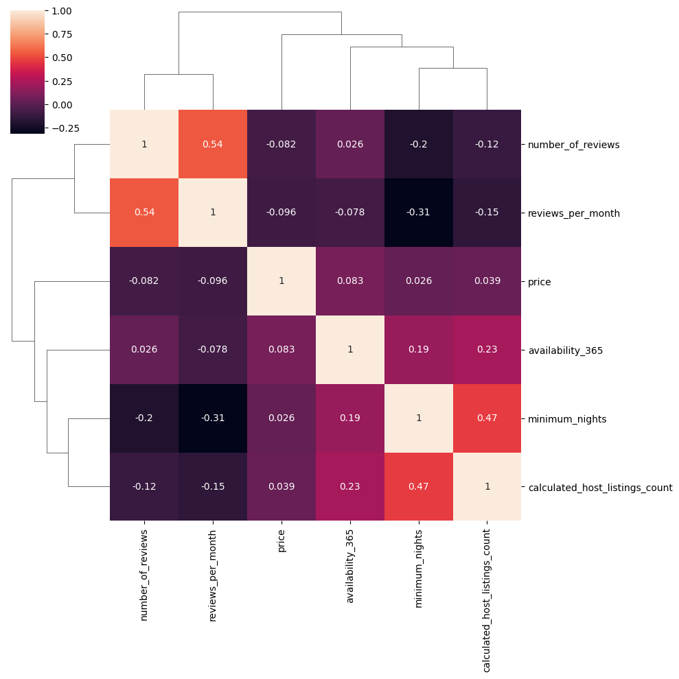

```python
sns.clustermap(df.drop(columns=["host_id", "latitude", "longitude"]).corr(), annot=True)
```

Análisis de correlación:

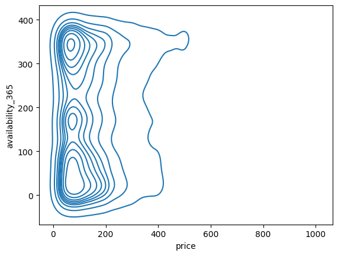

```python
sns.kdeplot(df[df.price < 1000], x="price", y="availability_365")
```

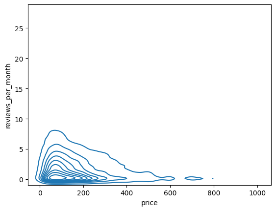

```python
sns.kdeplot(df[df.price < 1000], x="price", y="reviews_per_month")
```

Análisis de precio frente categóricas

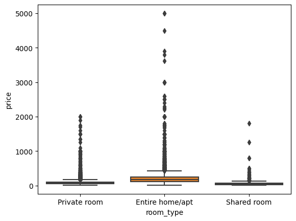

```python
sns.boxplot(df, x="room_type", y="price")
```

Se ve como a partir de 2000$ solo permanecen registros de apartamento entero, vamos a hacer zoom en la franja infeerior ***En realidad los hemos eliminado nosotros

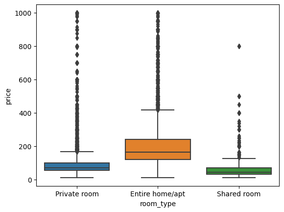

```python
sns.boxplot(df[df.price < 1000], x="room_type", y="price")
```

La mas cara es apartamento entero, aproximadamente el doble de habitación privada. La habitación compartida es la de menor precio medio y también la que menos registros de precio elevado

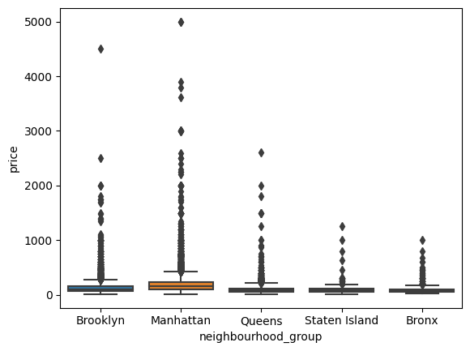

```python
sns.boxplot(df, x="neighbourhood_group", y="price")
```

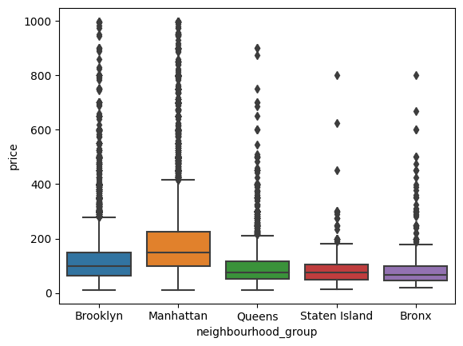

```python
sns.boxplot(df[df.price < 1000], x="neighbourhood_group", y="price")
```

Los máximos se encuentran fundamentalmente en Manhattan y también en Brooklyn. Parece razonable

Patrón esperado. Manhattan tiene el precio medio más alto y la mayor cantidad de valores elevados. Le sigue Brooklyn y por último, Queens, Bronx y Staten Island tienen distribuciones similares. En Staten Island parecee haber menos registros, quizá por su separación física del núcleo urbano

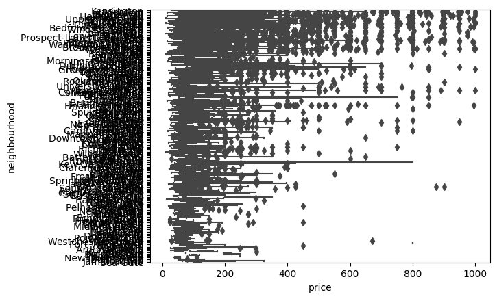

```python
sns.boxplot(df[df.price < 1000], x="price", y="neighbourhood")
```

```python
neigh = df.groupby(["neighbourhood_group", "neighbourhood"])["price"].agg(["count", "mean", "max"]).reset_index()
neigh
```

|  | neighbourhood_group | neighbourhood | count | mean | max |
| --- | --- | --- | --- | --- | --- |
| 0 | Bronx | Allerton | 37 | 91.702703 | 450 |
| 1 | Bronx | Baychester | 6 | 78.000000 | 101 |
| 2 | Bronx | Belmont | 17 | 85.823529 | 299 |
| 3 | Bronx | Bronxdale | 13 | 54.923077 | 100 |
| 4 | Bronx | Castle Hill | 9 | 63.000000 | 128 |
| ... | ... | ... | ... | ... | ... |
| 213 | Staten Island | Tompkinsville | 37 | 77.567568 | 245 |
| 214 | Staten Island | Tottenville | 7 | 144.857143 | 299 |
| 215 | Staten Island | West Brighton | 17 | 82.941176 | 200 |
| 216 | Staten Island | Westerleigh | 2 | 71.500000 | 103 |
| 217 | Staten Island | Willowbrook | 1 | 249.000000 | 249 |

218 rows × 5 columns

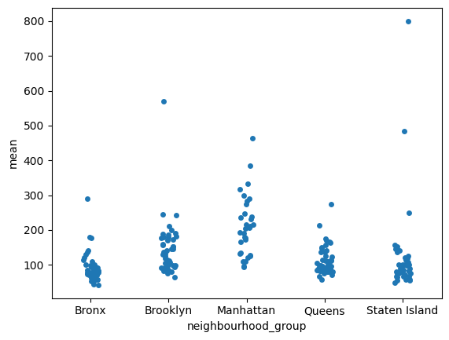

```python
sns.stripplot(neigh, x="neighbourhood_group", y="mean")
```

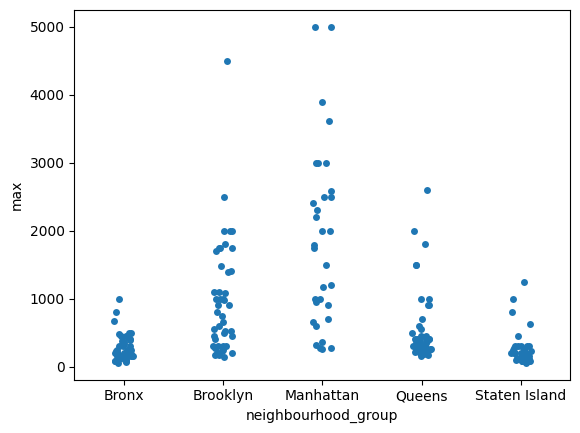

```python
sns.stripplot(neigh, x="neighbourhood_group", y="max")
```

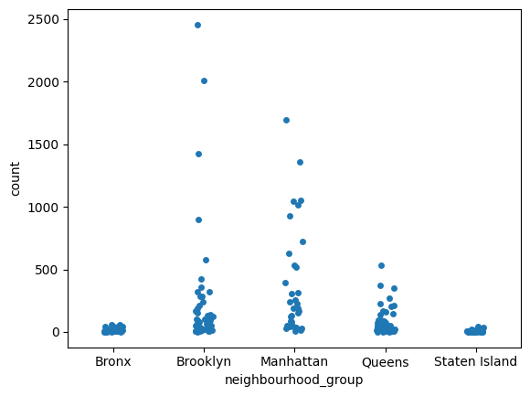

```python
sns.stripplot(neigh, x="neighbourhood_group", y="count")
```

```python
neigh.nlargest(5, columns="mean")
```

|  | neighbourhood_group | neighbourhood | count | mean | max |
| --- | --- | --- | --- | --- | --- |
| 187 | Staten Island | Fort Wadsworth | 1 | 800.000000 | 800 |
| 88 | Brooklyn | Sea Gate | 3 | 569.666667 | 1485 |
| 202 | Staten Island | Prince's Bay | 3 | 484.333333 | 1250 |
| 121 | Manhattan | Tribeca | 87 | 464.574713 | 2400 |
| 102 | Manhattan | Flatiron District | 46 | 385.260870 | 1750 |

```python
neigh.nlargest(5, columns="max")
```

|  | neighbourhood_group | neighbourhood | count | mean | max |
| --- | --- | --- | --- | --- | --- |
| 105 | Manhattan | Harlem | 1697 | 128.469652 | 5000 |
| 116 | Manhattan | Nolita | 128 | 275.234375 | 5000 |
| 61 | Brooklyn | Clinton Hill | 319 | 182.285266 | 4500 |
| 104 | Manhattan | Greenwich Village | 193 | 290.398964 | 3900 |
| 124 | Manhattan | Upper West Side | 1043 | 210.743049 | 3613 |

# Análisis precio en el mapa

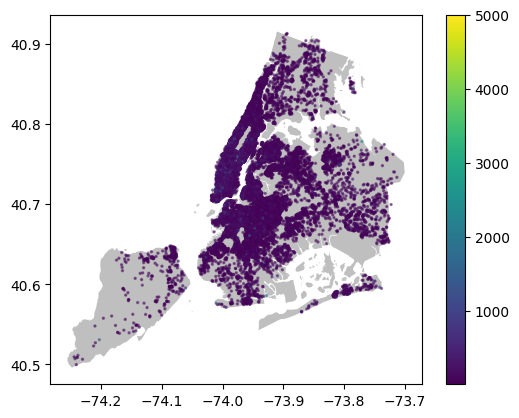

```python
geometry = [Point(xy) for xy in zip(df.longitude, df.latitude)]

# creamos el GeoPandas dataframe
geo_df = gpd.GeoDataFrame(df,
 crs = crs,
 geometry = geometry)

# dibujamos la silueta del mapa y los puntos por encima
fig, ax = plt.subplots()
street_map.plot(ax=ax, alpha=0.5, color="grey")
geo_df.plot(column="price", ax=ax, alpha=0.5, markersize=2, legend=True)
plt.show()
```

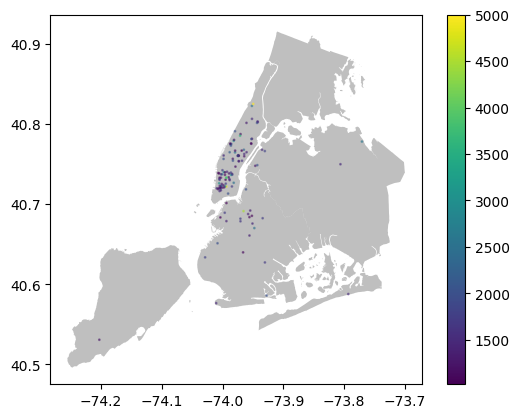

```python
geometry = [Point(xy) for xy in zip(df[df.price > 1000].longitude,
                                    df[df.price > 1000].latitude)]

# creamos el GeoPandas dataframe
geo_df = gpd.GeoDataFrame(df[df.price > 1000],
 crs = crs,
 geometry = geometry)

# dibujamos la silueta del mapa y los puntos por encima
fig, ax = plt.subplots()
street_map.plot(ax=ax, alpha=0.5, color="grey")
geo_df.plot(column="price", ax=ax, alpha=0.5, markersize=1, legend=True)
plt.show()
```

Supercandidatos

```python
supercandidates = df.loc[(df.room_type == "Entire home/apt") &
 (df.neighbourhood_group == "Manhattan") &
  (df.reviews_per_month < 3), "price"]
```

```python
print(f"El precio medio de los super candidatos es {supercandidates.mean()}")
print(f"El precio medio del resto es {df.loc[~df.index.isin(supercandidates.index), 'price'].mean()}")
```

```
El precio medio de los super candidatos es 257.0796652200868
El precio medio del resto es 124.93623948247432
```

Qué barrio tiene los apartamentos más caros en relación a su boro (distrito)? Cuál tiene el más caro?

```python
# Usamos window functions (groupby.transform en pandas)

df["price_ratio"] = df.groupby("neighbourhood_group")["price"].transform(lambda x: x/x.mean())
```

```python
df
```

|  | host_id | neighbourhood_group | neighbourhood | latitude | longitude | room_type | price | minimum_nights | number_of_reviews | reviews_per_month | calculated_host_listings_count | availability_365 | price_ratio |
| --- | --- | --- | --- | --- | --- | --- | --- | --- | --- | --- | --- | --- | --- |
| 0 | 2787 | Brooklyn | Kensington | 40.64749 | -73.97237 | Private room | 149 | 1 | 9 | 0.21 | 6 | 365 | 1.157052 |
| 1 | 2845 | Manhattan | Midtown | 40.75362 | -73.98377 | Entire home/apt | 225 | 1 | 45 | 0.38 | 2 | 355 | 1.122617 |
| 2 | 4632 | Manhattan | Harlem | 40.80902 | -73.94190 | Private room | 150 | 3 | 0 | 0.00 | 1 | 365 | 0.748411 |
| 3 | 4869 | Brooklyn | Clinton Hill | 40.68514 | -73.95976 | Entire home/apt | 89 | 1 | 270 | 4.64 | 1 | 194 | 0.691125 |
| 4 | 7322 | Manhattan | Murray Hill | 40.74767 | -73.97500 | Entire home/apt | 200 | 3 | 74 | 0.59 | 1 | 129 | 0.997882 |
| ... | ... | ... | ... | ... | ... | ... | ... | ... | ... | ... | ... | ... | ... |
| 30098 | 8232441 | Brooklyn | Bedford-Stuyvesant | 40.67853 | -73.94995 | Private room | 70 | 2 | 0 | 0.00 | 2 | 9 | 0.543582 |
| 30099 | 6570630 | Brooklyn | Bushwick | 40.70184 | -73.93317 | Private room | 40 | 4 | 0 | 0.00 | 2 | 36 | 0.310618 |
| 30100 | 23492952 | Manhattan | Harlem | 40.81475 | -73.94867 | Entire home/apt | 115 | 10 | 0 | 0.00 | 1 | 27 | 0.573782 |
| 30101 | 30985759 | Manhattan | Hell's Kitchen | 40.75751 | -73.99112 | Shared room | 55 | 1 | 0 | 0.00 | 6 | 2 | 0.274417 |
| 30102 | 68119814 | Manhattan | Hell's Kitchen | 40.76404 | -73.98933 | Private room | 90 | 7 | 0 | 0.00 | 1 | 23 | 0.449047 |

30103 rows × 13 columns

```python
df.groupby("neighbourhood")["price_ratio"].mean().sort_values(ascending=False)
```

```
neighbourhood
Fort Wadsworth        8.031833
Prince's Bay          4.862606
Sea Gate              4.423719
Riverdale             3.354791
Neponsit              2.730762
                        ...
Borough Park          0.507458
Mount Eden            0.491641
Port Richmond         0.489942
Washington Heights    0.479413
Inwood                0.471773
Name: price_ratio, Length: 218, dtype: float64
```

```python
df.sort_values("price_ratio", ascending=False)
```

|  | host_id | neighbourhood_group | neighbourhood | latitude | longitude | room_type | price | minimum_nights | number_of_reviews | reviews_per_month | calculated_host_listings_count | availability_365 | price_ratio |
| --- | --- | --- | --- | --- | --- | --- | --- | --- | --- | --- | --- | --- | --- |
| 3026 | 1177497 | Brooklyn | Clinton Hill | 40.69127 | -73.96563 | Entire home/apt | 4500 | 1 | 5 | 0.09 | 11 | 365 | 34.944536 |
| 24575 | 74373729 | Queens | Bayside | 40.77811 | -73.77069 | Entire home/apt | 2600 | 6 | 3 | 1.73 | 1 | 362 | 25.849443 |
| 2035 | 213266 | Manhattan | Nolita | 40.72193 | -73.99379 | Entire home/apt | 5000 | 1 | 2 | 0.03 | 1 | 365 | 24.947040 |
| 21310 | 172611460 | Manhattan | Harlem | 40.82511 | -73.94961 | Entire home/apt | 5000 | 1 | 2 | 0.38 | 2 | 150 | 24.947040 |
| 28613 | 35741633 | Queens | Long Island City | 40.74869 | -73.94294 | Entire home/apt | 2000 | 1 | 0 | 0.00 | 1 | 365 | 19.884187 |
| ... | ... | ... | ... | ... | ... | ... | ... | ... | ... | ... | ... | ... | ... |
| 5110 | 33106693 | Manhattan | Harlem | 40.82159 | -73.95013 | Private room | 16 | 2 | 43 | 1.66 | 3 | 154 | 0.079831 |
| 3181 | 16477306 | Manhattan | Upper East Side | 40.76866 | -73.95553 | Entire home/apt | 16 | 2 | 21 | 1.69 | 1 | 9 | 0.079831 |
| 29224 | 2967377 | Manhattan | Hell's Kitchen | 40.76279 | -73.99463 | Entire home/apt | 15 | 2 | 0 | 0.00 | 1 | 139 | 0.074841 |
| 14622 | 1144452 | Manhattan | Chelsea | 40.74045 | -74.00047 | Private room | 12 | 3 | 8 | 0.59 | 1 | 37 | 0.059873 |
| 27380 | 19342 | Manhattan | Upper West Side | 40.79900 | -73.96315 | Entire home/apt | 11 | 7 | 0 | 0.00 | 1 | 273 | 0.054883 |

30103 rows × 13 columns

```python
df.nlargest(3, columns="price_ratio").merge(apartment_details, left_index=True, right_index=True)
```

|  | host_id_x | neighbourhood_group | neighbourhood | latitude | longitude | room_type | price | minimum_nights | number_of_reviews | reviews_per_month | calculated_host_listings_count | availability_365 | price_ratio | name | host_name | host_id_y |
| --- | --- | --- | --- | --- | --- | --- | --- | --- | --- | --- | --- | --- | --- | --- | --- | --- |
| 3026 | 1177497 | Brooklyn | Clinton Hill | 40.69127 | -73.96563 | Entire home/apt | 4500 | 1 | 5 | 0.09 | 11 | 365 | 34.944536 | Sweet Apartment on Quiet Block | Liz | 367815 |
| 24575 | 74373729 | Queens | Bayside | 40.77811 | -73.77069 | Entire home/apt | 2600 | 6 | 3 | 1.73 | 1 | 362 | 25.849443 | Great location-Close to metro in cool neighbor... | Roberto | 81160897 |
| 2035 | 213266 | Manhattan | Nolita | 40.72193 | -73.99379 | Entire home/apt | 5000 | 1 | 2 | 0.03 | 1 | 365 | 24.947040 | Central Pk West-Convenient 1 BR | Joy | 4848828 |

```python
%%shell
jupyter nbconvert --to html '/content/drive/MyDrive/Colab Notebooks/Untitled8.ipynb'
```

```python
from google.colab import drive
drive.mount('/content/drive')
```